# Data Story on the History of Philosophy

Estelle Zhao

2021/9

[figure not shown]

The dataset “History of Philosophy” from Kaggle contains over 300,000 sentences from over 50 texts spanning 10 major schools of philosophy, which provides valuable data for us to understand the history of philosophy.

```r
packages.used=c("tm", "wordcloud", "RColorBrewer",
                "dplyr", "tidyverse", "DT", "wordcloud2", "jiebaRD","jiebaR","jpeg")
# check packages that need to be installed.
packages.needed=setdiff(packages.used,
                        intersect(installed.packages()[,1],
                                  packages.used))
# install additional packages
if(length(packages.needed)>0){
  install.packages(packages.needed, dependencies = TRUE,
                   repos='http://cran.us.r-project.org')
}
```

```r
library(tm)
```

```r
library(wordcloud)
library(RColorBrewer)
library(dplyr)
library(tidyverse)
library(DT)
library(reticulate)
library(wordcloud2)
library(jiebaR)
library(jiebaRD)
library(jpeg)
```

### Distribution of Philosophy Works

```r
dat <- read.csv("philosophy_data.csv", header = TRUE)
dat1 <- dat[!is.na(as.numeric(as.character(dat$sentence_length))),]
dat1 <- dat1[!is.na(as.numeric(as.character(dat1$original_publication_date))),]
```

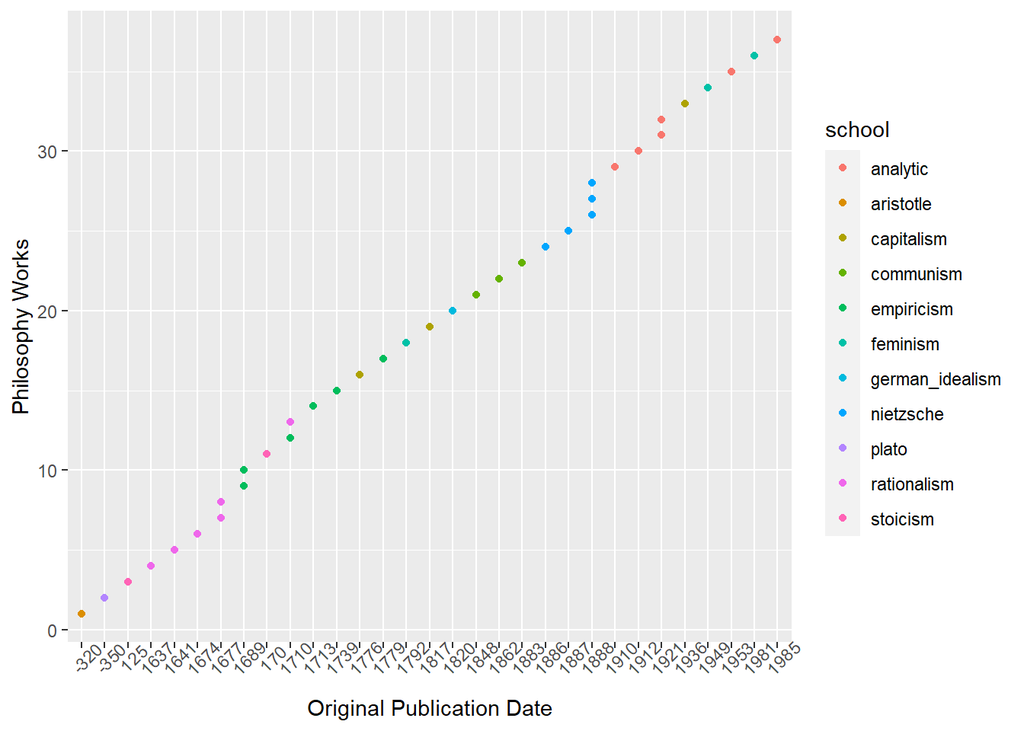

```r
dat3 <- dat1[!duplicated(dat1[,1]),]
dat3 <- dat3[order(dat3$original_publication_date),]
ggplot(data = dat3, mapping = aes(x = original_publication_date, y = c(1:37), color = school)) +
  geom_point() +
  xlab("Original Publication Date") + ylab("Philosophy Works")+
  theme(axis.text.x = element_text(hjust = 0.5, angle = 45))
```

### Change in Sentence Length

In order to explore the difference in sentence length between different schools, I sorted each school by the average of works’ publication date and used it as the x-axis. Then I calculated the average sentence length of each school as the height of the bar graph. It shows that the sentence length of early and late school works is shorter, while that of middle school works is longer. Maybe the philosophical language had a trend from concise to detailed and then condensed.

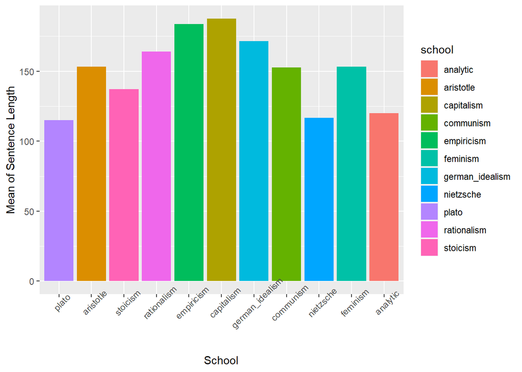

```r
sen <- tapply(as.numeric(dat1$sentence_length), dat1$school, mean)
school <- sort(unique(dat1$school))
year <- tapply(as.numeric(dat1$original_publication_date), dat1$school, mean)
s <- data.frame(school, year, sen)
ggplot(s) +
  geom_bar(mapping = aes(x = reorder(school, year), y = sen, fill = school),stat = "identity") +
  xlab("School") + ylab("Mean of Sentence Length")+
  theme(axis.text.x = element_text(hjust = 0.5, angle = 45))
```

### Key Words of Philosophy Works

I used word cloud to analyze the key points of philosophical sentences. We could intuitively see that words like “different”, “life”, “god”, “labour”, “animals” have high frequency in Philosophy works.

```r
# divide sentences
w <- dat1$sentence_lowered
mixseg<-worker("mix")
w<-segment(w,mixseg)
# remove stopwords, character(0), punctuation
removewords <- function(target_words,stop_words){
  target_words = target_words[target_words %in% stop_words == FALSE]
  return(target_words)
}
sw <- stopwords(kind = "en")
w2 <- sapply(w, FUN = removewords, sw)
w2 <- as.vector(unlist(w2))
a <- removeWords(w2, character(0))
b <- removePunctuation(w2)
freq<-table(w2) # word frequency
wordcloud2(freq)
```

[interactive chart not shown]